# Assignment 6

In this assignment, you'll analyze a collection of data sets from the [San Francisco Open Data Portal](http://data.sfgov.org/) and [Zillow](https://www.zillow.com/). The data sets have been stored in the SQLite database `sf_data.sqlite`, which you can [download here](http://anson.ucdavis.edu/~nulle/sf_data.sqlite). The database contains the following tables:

| Table | Description |
| --- | --- |
| `crime` | Crime reports dating back to 2010. |
| `mobile_food_locations` | List of all locations where mobile food vendors sell. |
| `mobile_food_permits` | List of all mobile food vendor permits. More details [here](https://data.sfgov.org/api/views/rqzj-sfat/files/8g2f5RV4PEk0_b24iJEtgEet9gnh_eA27GlqoOjjK4k?download=true&filename=DPW_DataDictionary_Mobil… |
| `mobile_food_schedule` | Schedules for mobile food vendors. |
| `noise` | Noise complaints dating back to August 2015. |
| `parking` | List of all parking lots. |
| `parks` | List of all parks. |
| `schools` | List of all schools. |
| `zillow` | Zillow rent and housing statistics dating back to 1996. More details [here](https://www.zillow.com/research/data/). |

The `mobile_food_` tables are explicitly connected through the `locationid` and `permit` columns. The other tables are not connected, but you may be able to connect them using dates, latitude/longitude, or postal codes.

Shapefiles for US postal codes are available [here](https://www.census.gov/geo/maps-data/data/cbf/cbf_zcta.html). These may be useful for converting latitude/longitude to postal codes.

Shapefiles for San Francisco Neighborhoods are available [here](https://data.sfgov.org/Geographic-Locations-and-Boundaries/SF-Find-Neighborhoods/pty2-tcw4).

```python
import sqlite3
import pandas
```

```python
con = sqlite3.connect("sf_data.sqlite")
cur = con.cursor()
```

```python
cur.execute("PRAGMA table_info('mobile_food_permits')")
cur.fetchall()
```

```
[(0, u'permit', u'TEXT', 0, None, 0),
 (1, u'Status', u'TEXT', 0, None, 0),
 (2, u'Applicant', u'TEXT', 0, None, 0),
 (3, u'FacilityType', u'TEXT', 0, None, 0),
 (4, u'FoodItems', u'TEXT', 0, None, 0),
 (5, u'PriorPermit', u'INTEGER', 0, None, 0),
 (6, u'Approved', u'TIMESTAMP', 0, None, 0),
 (7, u'Expiration', u'TIMESTAMP', 0, None, 0)]
```

```python
cur.execute("PRAGMA table_info('mobile_food_locations')")
cur.fetchall()
```

```
[(0, u'locationid', u'INTEGER', 0, None, 0),
 (1, u'LocationDescription', u'TEXT', 0, None, 0),
 (2, u'Address', u'TEXT', 0, None, 0),
 (3, u'Latitude', u'REAL', 0, None, 0),
 (4, u'Longitude', u'REAL', 0, None, 0)]
```

```python
cur.execute("PRAGMA table_info('mobile_food_schedule')")
cur.fetchall()
```

```
[(0, u'locationid', u'INTEGER', 0, None, 0),
 (1, u'permit', u'TEXT', 0, None, 0),
 (2, u'DayOfWeek', u'TEXT', 0, None, 0),
 (3, u'EndHour', u'INTEGER', 0, None, 0),
 (4, u'StartHour', u'INTEGER', 0, None, 0)]
```

**Exercise 1.1.** Which mobile food vendor(s) sells at the most locations?

```python
cur.execute("SELECT COUNT(mobile_food_schedule.locationid),mobile_food_schedule.permit,mobile_food_permits.Applicant FROM 'mobile_food_schedule','mobile_food_permits' WHERE mobile_food_permits.permit = mobile_food_schedule.permit GROUP BY mobile_food_schedule.permit ORDER BY COUNT(locationid) DESC")
cur.fetchone()
```

```
(340, u'17MFF-0110', u'May Catering')
```

**Exercise 1.2.** Ask and use the database to analyze 5 questions about San Francisco. For each question, write at least 150 words and support your answer with plots. Make a map for at least 2 of the 5 questions.

You should try to come up with some questions on your own, but these are examples of reasonable questions:

- Which parts of the city are the most and least expensive?
- Which parts of the city are the most dangerous (and at what times)?
- Are noise complaints and mobile food vendors related?
- What are the best times and places to find food trucks?
- Is there a relationship between housing prices and any of the other tables?

Please make sure to clearly state each of your questions in your submission.

```python
import matplotlib.pyplot as plt
import matplotlib.cm
from mpl_toolkits.basemap import Basemap
from matplotlib.patches import Polygon
from matplotlib.collections import PatchCollection
from matplotlib.colors import Normalize
import numpy as np
```

1. Are noise complaints and mobile food vendors related?

```python
plt.figure(0)
fig, ax = plt.subplots(figsize=(10,10))
m = Basemap(resolution='f',
            projection='merc',
            lat_0=54.5, lon_0=-4.36,
            llcrnrlon=-122.539444, llcrnrlat=37.701479 , urcrnrlon=-122.345123, urcrnrlat=37.814395)
m.readshapefile('geo_export_149e7bc4-f4bc-457f-a2b1-4a18803d3f70','hoods')
m.drawmapboundary(fill_color='#46bcec')
m.fillcontinents(color='#f2f2f2',lake_color='#46bcec',zorder=0)
m.drawcoastlines()

noise = pandas.read_sql_query("SELECT * FROM noise",con)
noise = noise.dropna()

x,y = m(list(noise['Lon']),list(noise['Lat']))
m.plot(x,y,'ro')
```

[figure not shown]

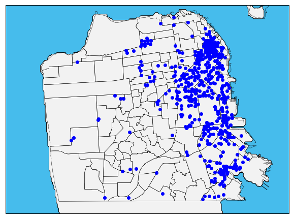

```python
plt.figure(1)
fig, ax = plt.subplots(figsize=(10,10))
n = Basemap(resolution='f',
            projection='merc',
            lat_0=54.5, lon_0=-4.36,
            llcrnrlon=-122.539444, llcrnrlat=37.701479 , urcrnrlon=-122.345123, urcrnrlat=37.814395)
n.readshapefile('geo_export_149e7bc4-f4bc-457f-a2b1-4a18803d3f70','hoods')
n.drawmapboundary(fill_color='#46bcec')
n.fillcontinents(color='#f2f2f2',lake_color='#46bcec',zorder=0)
n.drawcoastlines()

food = pandas.read_sql_query("SELECT * FROM mobile_food_locations",con)
food = food.dropna()

w,z = n(list(food['Longitude']),list(food['Latitude']))
n.plot(w,z,'bo')
plt.show()
```

For this question, we plotted locations of mobile food vendors and locations of noise complaints on 2 maps of San Fransisco. As we can see from the maps above, food vendor locations and noise complaints do seem to come from the same are, which is the north east part of San Francisco. As there are more noise complaints than there are food truck locations, the food truck points are less dense overall, However, there is a clear concentration on the eastern side of the city, and it gets even more concentrated on the north-east side of the city. There are many reasons why this may be the case. Food trucks are more likely to setup in areas with high concentrations of people. Areas with high concentrations of people are also more likely to receive noise complaints due to the number of people that complain/ number of people to complain about.

1. What are the best times and places to find food trucks?

```python
cur.execute('SELECT COUNT(permit),DayOfWeek from mobile_food_schedule GROUP BY DayOfWeek')
cur.fetchmany(20)
```

```
[(651, u'Fr'),
 (736, u'Mo'),
 (160, u'Sa'),
 (129, u'Su'),
 (638, u'Th'),
 (635, u'Tu'),
 (643, u'We')]
```

```python
times = pandas.read_sql_query('SELECT * FROM mobile_food_schedule',con)
Friday = pandas.read_sql_query('SELECT * FROM mobile_food_schedule WHERE DayOfWeek = "Fr"',con)
Monday = pandas.read_sql_query('SELECT * FROM mobile_food_schedule WHERE DayOfWeek = "Mo"',con)
Saturday = pandas.read_sql_query('SELECT * FROM mobile_food_schedule WHERE DayOfWeek = "Sa"',con)
Sunday = pandas.read_sql_query('SELECT * FROM mobile_food_schedule WHERE DayOfWeek = "Su"',con)
Thursday = pandas.read_sql_query('SELECT * FROM mobile_food_schedule WHERE DayOfWeek = "Th"',con)
Tuesday = pandas.read_sql_query('SELECT * FROM mobile_food_schedule WHERE DayOfWeek = "Tu"',con)
Wednesday = pandas.read_sql_query('SELECT * FROM mobile_food_schedule WHERE DayOfWeek = "We"',con)
```

```python
days = [Monday,Tuesday,Wednesday,Thursday,Friday,Saturday,Sunday]
daynames = ["Monday","Tuesday","Wednesday","Thursday","Friday","Saturday","Sunday"]
for i in xrange(7):
    f , plots =  plt.subplots(1,2,sharex= True,sharey=True)
    plots[0].hist(np.array(days[i]['StartHour']),bins = 24, color = 'blue')
    plots[1].hist(np.array(days[i]['EndHour']),bins = 24,color = 'red')
    plots[0].set_title('Start Time')
    plots[1].set_title('End Time')
    plots[0].set_ylim([0,160])
    plots[1].set_ylim([0,160])
    plt.suptitle(daynames[i])
```

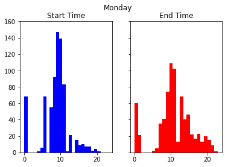

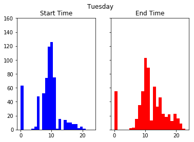

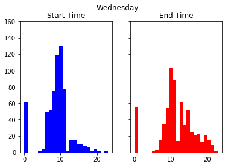

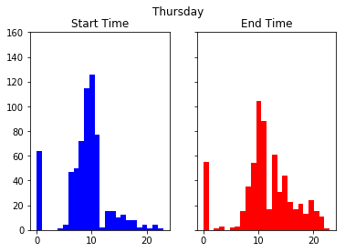

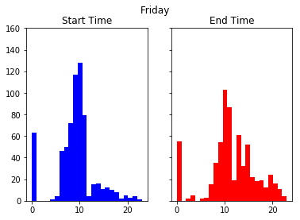

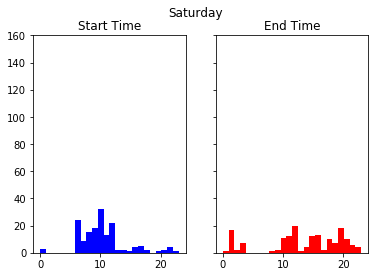

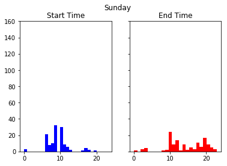

```python
 plt.show()
```

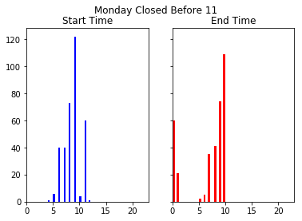

```python
f2 , plots2 =  plt.subplots(1,2,sharex= True,sharey=True)
plots2[0].hist(np.array(times[times['EndHour'] < 11][times['DayOfWeek'] == 'Mo']['StartHour']),bins = 24, color = 'blue')
plots2[1].hist(np.array(times[times['EndHour'] < 11][times['DayOfWeek'] == 'Mo']['EndHour']),bins = 24,color = 'red')
plots2[1].set_title('End Time')
plots2[0].set_title('Start Time')
plots2[0].set_xlim([0,23])
plots2[1].set_xlim([0,23])
plots[0].set_ylim([0,160])
plots[1].set_ylim([0,160])
plt.suptitle('Monday Closed Before 11')
plt.show()
```

For this question I tackled it in two parts, where and when. I refer back to question 1.2.1 and the map of San Francisco with mobile food vendors charted. The highest concentration of food trucks are gathered on the north east side of the city with good distribution all along the eastern side of the city. For the best time to find food trucks, first I counted the food trucks open on a given day of the week from the mobile_food_schedule database. From this I could see that the weekdays had far more foodtrucks open than the weekends, probably due to food vendors wanting to serve working people on their lunch breaks. We can see this play out when we look at histograms of start and end hours of the food trucks. Many open before lunch at 8-11 am and service lunch break hours, and many close at 2-4 when lunch breaks end. There is also a large number of food trucks that open before 9 and close from 9-10. These food truck presumably open for the breakfast crowd. Therefore, if you want to eat at a food truck for lunch, consider going to the north-east side of the city at 11-2, or from 8-10 to eat breakfast.

1. Which parts of the city are the most dangerous (and at what times)?

```python
crime = pandas.read_sql_query("SELECT * FROM crime WHERE Category != 'NON-CRIMINAL'",con)
crimetime = pandas.read_sql_query("SELECT DayOfWeek, Datetime FROM crime",con)
crimetimebyday = pandas.read_sql_query("SELECT DayOfWeek,COUNT(IncidntNum) FROM crime GROUP BY DayOfWeek",con)
```

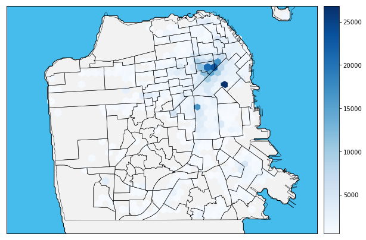

```python
fig, ax = plt.subplots(figsize=(10,10))
o = Basemap(resolution='f',
            projection='merc',
            lat_0=54.5, lon_0=-4.36,
            llcrnrlon=-122.539444, llcrnrlat=37.701479 , urcrnrlon=-122.345123, urcrnrlat=37.814395)
o.readshapefile('geo_export_149e7bc4-f4bc-457f-a2b1-4a18803d3f70','hoods')
o.drawmapboundary(fill_color='#46bcec')
o.fillcontinents(color='#f2f2f2',lake_color='#46bcec',zorder=0)
o.drawcoastlines()
a,b = o(list(crime['Lon']),list(crime['Lat']))
o.hexbin(np.array(a),np.array(b),cmap = plt.get_cmap("Blues"),mincnt = 500,gridsize = 35)
o.colorbar()
plt.show()
```

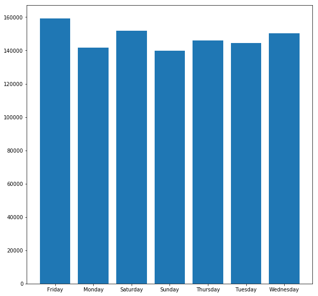

```python
days = []
for i in crimetimebyday['DayOfWeek']:
    i = str(i)
    days.append(i)
days.insert(0,' ')


fig,ax = plt.subplots(figsize = (10,10))
plt.bar(np.arange(7),crimetimebyday['COUNT(IncidntNum)'],)
ax.set_xticklabels(days)
plt.show()
```

```python
crimetime['Date'] = crimetime.Datetime.apply(lambda x: x[0:10])
crimetime['Time'] = crimetime.Datetime.apply(lambda x: x[11:])
```

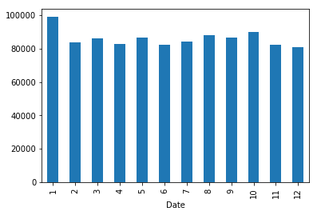

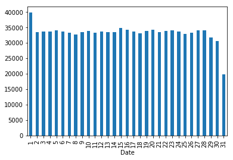

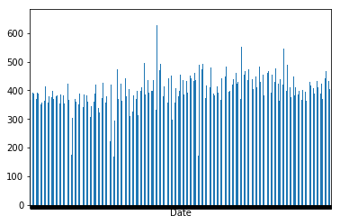

```python
crimetime.Date = crimetime.Date.astype("datetime64")
crimetime.Date.groupby(crimetime.Date.dt.month).count().plot(kind="bar")
plt.show()
crimetime.Date.groupby(crimetime.Date.dt.day).count().plot(kind="bar")
plt.show()
crimetime.Date.groupby(crimetime.Date.dt.date).count().plot(kind="bar")
plt.tick_params(labelbottom='off')
plt.show()
```

1. Public Schools vs Private Schools?

```python
school = pandas.read_sql_query('SELECT * FROM schools',con)
private = school[school['Entity'] == 'Private']
public = school[school['Entity'] != 'Private']
```

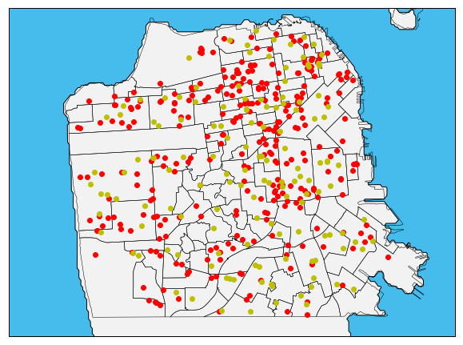

```python
fig, ax = plt.subplots(figsize=(10,10))
p = Basemap(resolution='f',
            projection='merc',
            lat_0=54.5, lon_0=-4.36,
            llcrnrlon=-122.539444, llcrnrlat=37.701479 , urcrnrlon=-122.345123, urcrnrlat=37.814395)
p.readshapefile('geo_export_149e7bc4-f4bc-457f-a2b1-4a18803d3f70','hoods')
p.drawmapboundary(fill_color='#46bcec')
p.fillcontinents(color='#f2f2f2',lake_color='#46bcec',zorder=0)
p.drawcoastlines()
c,d = o(list(private['Lon']),list(private['Lat']))
e,f = o(list(public['Lon']),list(public['Lat']))
o.plot(c,d,'ro')
o.plot(e,f,'yo')
plt.show()
```

For this problem, we compare the maps of crime and schools. For the School Map, we plotted the schools in the city and color coded them based on if they are private or public. Private schools are colored in red while public schools are colored in yellow. Looking at the distribution of schools, it seems that schools are evenly distributed with only a slightly higher concentration in the north-eastern side of the city. Furthermore, comparing public schools and private schools, private schools are slightly more concentrated in the northeast side of the city, indicating that there may be more people in the northeastern part of the city and/or they may be more affluent than the rest of the city (due to the fact private schools can choose to locate where they generate the most profit, either with the most students our the highest tuition prices, while public schools are uniformly distributed, presumeably by the government.

1. What is the relationship between housing price and Robberies?

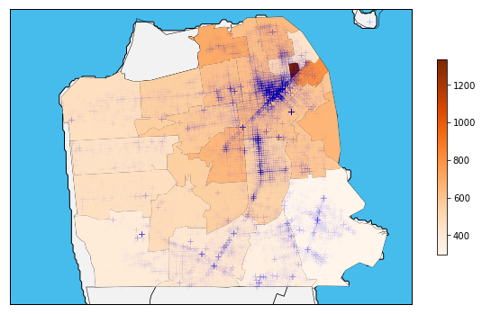

```python
fig, ax = plt.subplots(figsize=(10,10))
q = Basemap(resolution='f',
            projection='merc',
            lat_0=54.5, lon_0=-4.36,
            llcrnrlon=-122.539444, llcrnrlat=37.701479 , urcrnrlon=-122.345123, urcrnrlat=37.814395)
q.readshapefile('cb_2015_us_zcta510_500k','zip')
q.drawmapboundary(fill_color='#46bcec')
q.fillcontinents(color='#f2f2f2',lake_color='#46bcec',zorder=0)
q.drawcoastlines()
zillow = pandas.read_sql_query('SELECT RegionName,AVG(MedianSoldPricePerSqft_AllHomes) FROM zillow GROUP BY RegionName',con)
zillow.RegionName = zillow.RegionName.astype(str)
df_poly = pandas.DataFrame({
        'shapes': [Polygon(np.array(shape), True) for shape in q.zip],
        'RegionName': [area['GEOID10'] for area in q.zip_info]
    })
df_poly = df_poly.merge(zillow, on='RegionName',how = 'outer')
df_poly = df_poly.dropna()
cmap = plt.get_cmap('Oranges')
pc = PatchCollection(df_poly.shapes, zorder=2)
norm = Normalize()

pc.set_facecolor(cmap(norm((df_poly['AVG(MedianSoldPricePerSqft_AllHomes)'].fillna(0).values))))
ax.add_collection(pc)
mapper = matplotlib.cm.ScalarMappable(norm=norm, cmap=cmap)
mapper.set_array(df_poly['AVG(MedianSoldPricePerSqft_AllHomes)'].dropna())
plt.colorbar(mapper, shrink=0.4)
robs = crime[crime['Category'] == 'ROBBERY']
a,b = q(list(robs['Lon']),list(robs['Lat']))
q.plot(a,b,'b+',alpha = .01)
plt.show()
```

For this question, I plotted housing prices and colored in the zip code areas based on average median house price per square foot, where darker colors are more expensive areas. On top of this I plotted a subset of crimes (Robberies) and plotted them with high transparancy, so that it was easy to distinguish between high density of crime areas and low density of crime areas. As you can see from the map, housing prices are highest on the north-eastern side of the city, and robberies are also most frequent in the north-eastern side of the city. This makes sense as robbers will choose target expensive homes instead of wasting their time on poorer homes in order to maximize their risk vs reward. We can conclude based on this map that crime and housing price are positively correlated, and that expensive areas have higher incedence of robberies than poorer areas.